# Telco_Customer_Churn method

### **Problem Statement**

**Business Context:**

**ML Objective:**

to build a neural network to predict the churn 30 days in advance by using:

Input: Contract details, service usage, payment history

Output: Churn probability (0-1)

**Dataset:**

[IBM Telco Customer Churn](https://www.kaggle.com/datasets/blastchar/telco-customer-churn?resource=download)

**1: Install & Import Libraries**

Installing and imports libraries for data processing and visualization also for deep learning and Set random seeds for reproducibility

```python
!pip install -q tensorflow scikit-learn pandas-profiling
import pandas as pd
import numpy as np
import matplotlib.pyplot as plt
import seaborn as sns
from sklearn.model_selection import train_test_split
from sklearn.preprocessing import StandardScaler, OneHotEncoder
from sklearn.compose import ColumnTransformer
from sklearn.metrics import classification_report, roc_auc_score, roc_curve
import tensorflow as tf
from tensorflow import keras
from tensorflow.keras import layers, callbacks


np.random.seed(42)
tf.random.set_seed(42)
```

**2: Load Data & Cleaning**

Loads dataset

Fixeing missing values

```python
df = pd.read_csv('/content/WA_Fn-UseC_-Telco-Customer-Churn.csv')
print(f"Data shape: {df.shape}")


df['TotalCharges'] = pd.to_numeric(df['TotalCharges'], errors='coerce')
df['TotalCharges'].fillna(df['TotalCharges'].median(), inplace=True)
df['Churn'] = df['Churn'].map({'Yes':1, 'No':0})


print("\nMissing values check:")
print(df.isna().sum())
```

```
Data shape: (7043, 21)

Missing values check:
customerID          0
gender              0
SeniorCitizen       0
Partner             0
Dependents          0
tenure              0
PhoneService        0
MultipleLines       0
InternetService     0
OnlineSecurity      0
OnlineBackup        0
DeviceProtection    0
TechSupport         0
StreamingTV         0
StreamingMovies     0
Contract            0
PaperlessBilling    0
PaymentMethod       0
MonthlyCharges      0
TotalCharges        0
Churn               0
dtype: int64
```

**3: Data Visualization**

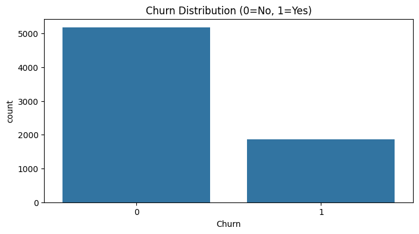

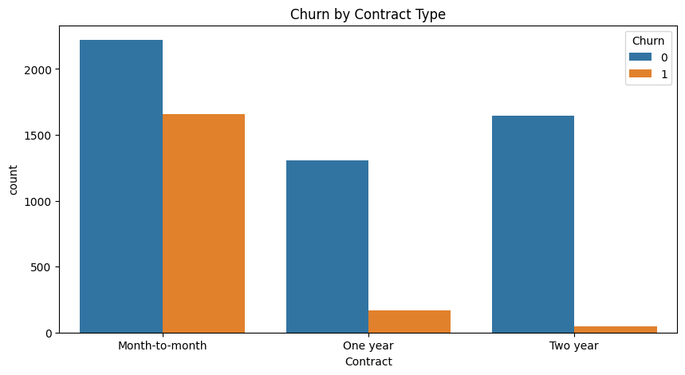

```python
plt.figure(figsize=(8,4))
sns.countplot(x='Churn', data=df)
plt.title('Churn Distribution (0=No, 1=Yes)')
plt.show()


plt.figure(figsize=(10,5))
sns.countplot(x='Contract', hue='Churn', data=df)
plt.title('Churn by Contract Type')
plt.show()
```

**4: Preprocessing Pipeline**

```python
df['MonthlyValue'] = df['TotalCharges'] / (df['tenure'] + 1)
df['ServiceDensity'] = df.filter(like='Service').apply(lambda x: x == 'Yes').sum(axis=1)


X = df.drop(['customerID', 'Churn'], axis=1)
y = df['Churn']


X_train, X_test, y_train, y_test = train_test_split(
    X, y, test_size=0.2, stratify=y, random_state=42)

numeric_features = ['tenure', 'MonthlyCharges', 'TotalCharges', 'MonthlyValue', 'ServiceDensity']
categorical_features = ['Contract', 'InternetService', 'PaymentMethod']

preprocessor = ColumnTransformer([
    ('num', StandardScaler(), numeric_features),
    ('cat', OneHotEncoder(drop='first'), categorical_features)
])

X_train_processed = preprocessor.fit_transform(X_train)
X_test_processed = preprocessor.transform(X_test)
```

**5: Build & Train Model**

```python
keras.backend.clear_session()


model = keras.Sequential([
    layers.Dense(128, activation='relu', input_shape=(X_train_processed.shape[1],)),
    layers.BatchNormalization(),
    layers.Dropout(0.4),
    layers.Dense(64, activation='relu'),
    layers.Dropout(0.3),
    layers.Dense(1, activation='sigmoid')
])


model.compile(
    optimizer=keras.optimizers.Adam(learning_rate=0.001),
    loss='binary_crossentropy',
    metrics=['Recall', 'AUC', 'Precision'])


early_stop = callbacks.EarlyStopping(
    monitor='val_recall',
    patience=10,
    mode='max',
    restore_best_weights=True)

history = model.fit(
    X_train_processed, y_train,
    validation_split=0.2,
    epochs=100,
    batch_size=64,
    class_weight={0:1, 1:3},
    callbacks=[early_stop],
    verbose=1)
```

```
71/71 ━━━━━━━━━━━━━━━━━━━━ 3s 11ms/step - AUC: 0.7465 - Precision: 0.4313 - Recall: 0.7039 - loss: 1.0312 - val_AUC: 0.8071 - val_Precision: 0.4549 - val_Recall: 0.8034 - val_loss: 0.5996
38/71 ━━━━━━━━━━━━━━━━━━━━ 0s 3ms/step - AUC: 0.7959 - Precision: 0.4674 - Recall: 0.7707 - loss: 0.8672
```

```
71/71 ━━━━━━━━━━━━━━━━━━━━ 0s 4ms/step - AUC: 0.7964 - Precision: 0.4677 - Recall: 0.7772 - loss: 0.8667 - val_AUC: 0.8137 - val_Precision: 0.4733 - val_Recall: 0.8102 - val_loss: 0.5772
71/71 ━━━━━━━━━━━━━━━━━━━━ 1s 9ms/step - AUC: 0.8158 - Precision: 0.4778 - Recall: 0.7991 - loss: 0.8205 - val_AUC: 0.8136 - val_Precision: 0.4748 - val_Recall: 0.7661 - val_loss: 0.5550
```

```
71/71 ━━━━━━━━━━━━━━━━━━━━ 1s 9ms/step - AUC: 0.8255 - Precision: 0.5001 - Recall: 0.8014 - loss: 0.7900 - val_AUC: 0.8130 - val_Precision: 0.4710 - val_Recall: 0.7695 - val_loss: 0.5425
24/71 ━━━━━━━━━━━━━━━━━━━━ 0s 5ms/step - AUC: 0.8314 - Precision: 0.4894 - Recall: 0.8292 - loss: 0.7715
```

```
71/71 ━━━━━━━━━━━━━━━━━━━━ 1s 7ms/step - AUC: 0.8263 - Precision: 0.4861 - Recall: 0.8093 - loss: 0.7841 - val_AUC: 0.8164 - val_Precision: 0.4765 - val_Recall: 0.7898 - val_loss: 0.5328
 1/71 ━━━━━━━━━━━━━━━━━━━━ 8s 125ms/step - AUC: 0.8123 - Precision: 0.5185 - Recall: 0.8235 - loss: 0.8273
```

```
71/71 ━━━━━━━━━━━━━━━━━━━━ 1s 6ms/step - AUC: 0.8248 - Precision: 0.4898 - Recall: 0.8019 - loss: 0.7912 - val_AUC: 0.8135 - val_Precision: 0.4684 - val_Recall: 0.7797 - val_loss: 0.5362
```

```
71/71 ━━━━━━━━━━━━━━━━━━━━ 0s 4ms/step - AUC: 0.8304 - Precision: 0.4953 - Recall: 0.8004 - loss: 0.7698 - val_AUC: 0.8147 - val_Precision: 0.4751 - val_Recall: 0.7763 - val_loss: 0.5341
71/71 ━━━━━━━━━━━━━━━━━━━━ 1s 4ms/step - AUC: 0.8312 - Precision: 0.4905 - Recall: 0.8091 - loss: 0.7754 - val_AUC: 0.8162 - val_Precision: 0.4779 - val_Recall: 0.7695 - val_loss: 0.5381
```

```
71/71 ━━━━━━━━━━━━━━━━━━━━ 1s 4ms/step - AUC: 0.8367 - Precision: 0.4996 - Recall: 0.8121 - loss: 0.7599 - val_AUC: 0.8173 - val_Precision: 0.4739 - val_Recall: 0.7695 - val_loss: 0.5359
71/71 ━━━━━━━━━━━━━━━━━━━━ 0s 5ms/step - AUC: 0.8373 - Precision: 0.5082 - Recall: 0.8152 - loss: 0.7558 - val_AUC: 0.8177 - val_Precision: 0.4669 - val_Recall: 0.7661 - val_loss: 0.5343
71/71 ━━━━━━━━━━━━━━━━━━━━ 0s 5ms/step - AUC: 0.8403 - Precision: 0.4999 - Recall: 0.8101 - loss: 0.7483 - val_AUC: 0.8217 - val_Precision: 0.4680 - val_Recall: 0.7932 - val_loss: 0.5400
56/71 ━━━━━━━━━━━━━━━━━━━━ 0s 3ms/step - AUC: 0.8387 - Precision: 0.5012 - Recall: 0.8292 - loss: 0.7504
```

```
71/71 ━━━━━━━━━━━━━━━━━━━━ 0s 5ms/step - AUC: 0.8386 - Precision: 0.5000 - Recall: 0.8285 - loss: 0.7507 - val_AUC: 0.8202 - val_Precision: 0.4763 - val_Recall: 0.7831 - val_loss: 0.5365
71/71 ━━━━━━━━━━━━━━━━━━━━ 1s 5ms/step - AUC: 0.8421 - Precision: 0.5035 - Recall: 0.8203 - loss: 0.7430 - val_AUC: 0.8205 - val_Precision: 0.4772 - val_Recall: 0.7797 - val_loss: 0.5364
13/71 ━━━━━━━━━━━━━━━━━━━━ 0s 10ms/step - AUC: 0.8444 - Precision: 0.5157 - Recall: 0.8022 - loss: 0.7303
```

```
71/71 ━━━━━━━━━━━━━━━━━━━━ 0s 6ms/step - AUC: 0.8360 - Precision: 0.5007 - Recall: 0.8038 - loss: 0.7625 - val_AUC: 0.8210 - val_Precision: 0.4793 - val_Recall: 0.7831 - val_loss: 0.5355
```

```
71/71 ━━━━━━━━━━━━━━━━━━━━ 1s 4ms/step - AUC: 0.8418 - Precision: 0.5054 - Recall: 0.8129 - loss: 0.7472 - val_AUC: 0.8215 - val_Precision: 0.4673 - val_Recall: 0.7763 - val_loss: 0.5347
71/71 ━━━━━━━━━━━━━━━━━━━━ 0s 7ms/step - AUC: 0.8459 - Precision: 0.5065 - Recall: 0.8129 - loss: 0.7392 - val_AUC: 0.8216 - val_Precision: 0.4660 - val_Recall: 0.7898 - val_loss: 0.5386
 1/71 ━━━━━━━━━━━━━━━━━━━━ 10s 152ms/step - AUC: 0.8673 - Precision: 0.5600 - Recall: 0.8235 - loss: 0.6784
```

```
71/71 ━━━━━━━━━━━━━━━━━━━━ 0s 4ms/step - AUC: 0.8448 - Precision: 0.5062 - Recall: 0.8265 - loss: 0.7385 - val_AUC: 0.8213 - val_Precision: 0.4679 - val_Recall: 0.7898 - val_loss: 0.5431
71/71 ━━━━━━━━━━━━━━━━━━━━ 0s 4ms/step - AUC: 0.8435 - Precision: 0.5072 - Recall: 0.8195 - loss: 0.7374 - val_AUC: 0.8222 - val_Precision: 0.4695 - val_Recall: 0.8339 - val_loss: 0.5418
71/71 ━━━━━━━━━━━━━━━━━━━━ 1s 6ms/step - AUC: 0.8400 - Precision: 0.5077 - Recall: 0.8089 - loss: 0.7493 - val_AUC: 0.8233 - val_Precision: 0.4809 - val_Recall: 0.7695 - val_loss: 0.5359
56/71 ━━━━━━━━━━━━━━━━━━━━ 0s 3ms/step - AUC: 0.8453 - Precision: 0.5183 - Recall: 0.8206 - loss: 0.7410
```

```
71/71 ━━━━━━━━━━━━━━━━━━━━ 0s 5ms/step - AUC: 0.8449 - Precision: 0.5174 - Recall: 0.8201 - loss: 0.7423 - val_AUC: 0.8226 - val_Precision: 0.4733 - val_Recall: 0.8102 - val_loss: 0.5417
```

```
71/71 ━━━━━━━━━━━━━━━━━━━━ 1s 4ms/step - AUC: 0.8465 - Precision: 0.5108 - Recall: 0.8162 - loss: 0.7304 - val_AUC: 0.8233 - val_Precision: 0.4718 - val_Recall: 0.7932 - val_loss: 0.5370
71/71 ━━━━━━━━━━━━━━━━━━━━ 0s 5ms/step - AUC: 0.8445 - Precision: 0.5087 - Recall: 0.8020 - loss: 0.7370 - val_AUC: 0.8220 - val_Precision: 0.4730 - val_Recall: 0.7729 - val_loss: 0.5359
```

```
71/71 ━━━━━━━━━━━━━━━━━━━━ 1s 4ms/step - AUC: 0.8455 - Precision: 0.5165 - Recall: 0.8135 - loss: 0.7350 - val_AUC: 0.8223 - val_Precision: 0.4701 - val_Recall: 0.8000 - val_loss: 0.5452
71/71 ━━━━━━━━━━━━━━━━━━━━ 1s 4ms/step - AUC: 0.8438 - Precision: 0.5062 - Recall: 0.8101 - loss: 0.7433 - val_AUC: 0.8220 - val_Precision: 0.4672 - val_Recall: 0.7729 - val_loss: 0.5367
```

```
71/71 ━━━━━━━━━━━━━━━━━━━━ 1s 8ms/step - AUC: 0.8458 - Precision: 0.5111 - Recall: 0.7995 - loss: 0.7326 - val_AUC: 0.8231 - val_Precision: 0.4697 - val_Recall: 0.8136 - val_loss: 0.5423
21/71 ━━━━━━━━━━━━━━━━━━━━ 0s 5ms/step - AUC: 0.8536 - Precision: 0.5080 - Recall: 0.8218 - loss: 0.7184
```

```
71/71 ━━━━━━━━━━━━━━━━━━━━ 1s 7ms/step - AUC: 0.8472 - Precision: 0.5123 - Recall: 0.8140 - loss: 0.7356 - val_AUC: 0.8220 - val_Precision: 0.4711 - val_Recall: 0.7729 - val_loss: 0.5345
71/71 ━━━━━━━━━━━━━━━━━━━━ 1s 7ms/step - AUC: 0.8461 - Precision: 0.5222 - Recall: 0.8116 - loss: 0.7332 - val_AUC: 0.8218 - val_Precision: 0.4686 - val_Recall: 0.7831 - val_loss: 0.5455
71/71 ━━━━━━━━━━━━━━━━━━━━ 1s 7ms/step - AUC: 0.8437 - Precision: 0.5022 - Recall: 0.8063 - loss: 0.7426 - val_AUC: 0.8221 - val_Precision: 0.4699 - val_Recall: 0.7932 - val_loss: 0.5421
19/71 ━━━━━━━━━━━━━━━━━━━━ 0s 3ms/step - AUC: 0.8557 - Precision: 0.5245 - Recall: 0.8316 - loss: 0.7157
```

```
71/71 ━━━━━━━━━━━━━━━━━━━━ 0s 4ms/step - AUC: 0.8510 - Precision: 0.5232 - Recall: 0.8224 - loss: 0.7280 - val_AUC: 0.8224 - val_Precision: 0.4762 - val_Recall: 0.7797 - val_loss: 0.5356
71/71 ━━━━━━━━━━━━━━━━━━━━ 0s 6ms/step - AUC: 0.8480 - Precision: 0.5184 - Recall: 0.8063 - loss: 0.7316 - val_AUC: 0.8219 - val_Precision: 0.4653 - val_Recall: 0.7966 - val_loss: 0.5388
```

```
71/71 ━━━━━━━━━━━━━━━━━━━━ 0s 4ms/step - AUC: 0.8470 - Precision: 0.5094 - Recall: 0.8159 - loss: 0.7311 - val_AUC: 0.8220 - val_Precision: 0.4706 - val_Recall: 0.7864 - val_loss: 0.5391
```

```
71/71 ━━━━━━━━━━━━━━━━━━━━ 1s 6ms/step - AUC: 0.8494 - Precision: 0.5116 - Recall: 0.8136 - loss: 0.7254 - val_AUC: 0.8231 - val_Precision: 0.4735 - val_Recall: 0.8169 - val_loss: 0.5382
```

```
71/71 ━━━━━━━━━━━━━━━━━━━━ 1s 4ms/step - AUC: 0.8454 - Precision: 0.5078 - Recall: 0.8130 - loss: 0.7370 - val_AUC: 0.8214 - val_Precision: 0.4698 - val_Recall: 0.7898 - val_loss: 0.5459
71/71 ━━━━━━━━━━━━━━━━━━━━ 0s 4ms/step - AUC: 0.8509 - Precision: 0.5156 - Recall: 0.8227 - loss: 0.7244 - val_AUC: 0.8232 - val_Precision: 0.4734 - val_Recall: 0.7831 - val_loss: 0.5374
71/71 ━━━━━━━━━━━━━━━━━━━━ 0s 4ms/step - AUC: 0.8505 - Precision: 0.5172 - Recall: 0.8286 - loss: 0.7259 - val_AUC: 0.8229 - val_Precision: 0.4668 - val_Recall: 0.7864 - val_loss: 0.5395
71/71 ━━━━━━━━━━━━━━━━━━━━ 1s 4ms/step - AUC: 0.8477 - Precision: 0.5221 - Recall: 0.8262 - loss: 0.7265 - val_AUC: 0.8232 - val_Precision: 0.4728 - val_Recall: 0.8237 - val_loss: 0.5441
29/71 ━━━━━━━━━━━━━━━━━━━━ 0s 6ms/step - AUC: 0.8540 - Precision: 0.5210 - Recall: 0.8257 - loss: 0.7192
```

```
71/71 ━━━━━━━━━━━━━━━━━━━━ 0s 5ms/step - AUC: 0.8504 - Precision: 0.5184 - Recall: 0.8208 - loss: 0.7272 - val_AUC: 0.8231 - val_Precision: 0.4707 - val_Recall: 0.7898 - val_loss: 0.5418
```

```
71/71 ━━━━━━━━━━━━━━━━━━━━ 1s 4ms/step - AUC: 0.8491 - Precision: 0.5292 - Recall: 0.8313 - loss: 0.7286 - val_AUC: 0.8233 - val_Precision: 0.4705 - val_Recall: 0.8102 - val_loss: 0.5402
71/71 ━━━━━━━━━━━━━━━━━━━━ 0s 5ms/step - AUC: 0.8527 - Precision: 0.5194 - Recall: 0.8228 - loss: 0.7176 - val_AUC: 0.8226 - val_Precision: 0.4745 - val_Recall: 0.8203 - val_loss: 0.5411
59/71 ━━━━━━━━━━━━━━━━━━━━ 0s 3ms/step - AUC: 0.8535 - Precision: 0.5234 - Recall: 0.8219 - loss: 0.7183
```

```
71/71 ━━━━━━━━━━━━━━━━━━━━ 0s 4ms/step - AUC: 0.8532 - Precision: 0.5228 - Recall: 0.8212 - loss: 0.7192 - val_AUC: 0.8228 - val_Precision: 0.4764 - val_Recall: 0.8203 - val_loss: 0.5399
71/71 ━━━━━━━━━━━━━━━━━━━━ 0s 4ms/step - AUC: 0.8497 - Precision: 0.5111 - Recall: 0.8214 - loss: 0.7267 - val_AUC: 0.8222 - val_Precision: 0.4760 - val_Recall: 0.7729 - val_loss: 0.5359
71/71 ━━━━━━━━━━━━━━━━━━━━ 1s 6ms/step - AUC: 0.8480 - Precision: 0.5189 - Recall: 0.8097 - loss: 0.7317 - val_AUC: 0.8232 - val_Precision: 0.4753 - val_Recall: 0.8169 - val_loss: 0.5379
```

```
71/71 ━━━━━━━━━━━━━━━━━━━━ 1s 4ms/step - AUC: 0.8501 - Precision: 0.5170 - Recall: 0.8189 - loss: 0.7267 - val_AUC: 0.8228 - val_Precision: 0.4752 - val_Recall: 0.7797 - val_loss: 0.5330
71/71 ━━━━━━━━━━━━━━━━━━━━ 0s 5ms/step - AUC: 0.8529 - Precision: 0.5170 - Recall: 0.8152 - loss: 0.7159 - val_AUC: 0.8229 - val_Precision: 0.4778 - val_Recall: 0.7661 - val_loss: 0.5299
38/71 ━━━━━━━━━━━━━━━━━━━━ 0s 3ms/step - AUC: 0.8577 - Precision: 0.5251 - Recall: 0.8139 - loss: 0.7069
```

```
71/71 ━━━━━━━━━━━━━━━━━━━━ 0s 4ms/step - AUC: 0.8550 - Precision: 0.5236 - Recall: 0.8155 - loss: 0.7136 - val_AUC: 0.8229 - val_Precision: 0.4735 - val_Recall: 0.8169 - val_loss: 0.5380
71/71 ━━━━━━━━━━━━━━━━━━━━ 0s 4ms/step - AUC: 0.8547 - Precision: 0.5124 - Recall: 0.8141 - loss: 0.7149 - val_AUC: 0.8209 - val_Precision: 0.4761 - val_Recall: 0.7763 - val_loss: 0.5426
71/71 ━━━━━━━━━━━━━━━━━━━━ 1s 5ms/step - AUC: 0.8502 - Precision: 0.5223 - Recall: 0.8248 - loss: 0.7251 - val_AUC: 0.8230 - val_Precision: 0.4744 - val_Recall: 0.7864 - val_loss: 0.5310
```

```
71/71 ━━━━━━━━━━━━━━━━━━━━ 1s 4ms/step - AUC: 0.8495 - Precision: 0.5239 - Recall: 0.8067 - loss: 0.7264 - val_AUC: 0.8240 - val_Precision: 0.4745 - val_Recall: 0.8203 - val_loss: 0.5372
71/71 ━━━━━━━━━━━━━━━━━━━━ 1s 9ms/step - AUC: 0.8539 - Precision: 0.5248 - Recall: 0.8218 - loss: 0.7119 - val_AUC: 0.8221 - val_Precision: 0.4646 - val_Recall: 0.8000 - val_loss: 0.5436
27/71 ━━━━━━━━━━━━━━━━━━━━ 0s 4ms/step - AUC: 0.8605 - Precision: 0.5246 - Recall: 0.8466 - loss: 0.7035
```

```
71/71 ━━━━━━━━━━━━━━━━━━━━ 0s 6ms/step - AUC: 0.8556 - Precision: 0.5214 - Recall: 0.8339 - loss: 0.7147 - val_AUC: 0.8218 - val_Precision: 0.4744 - val_Recall: 0.7864 - val_loss: 0.5387
71/71 ━━━━━━━━━━━━━━━━━━━━ 1s 6ms/step - AUC: 0.8532 - Precision: 0.5269 - Recall: 0.8167 - loss: 0.7199 - val_AUC: 0.8224 - val_Precision: 0.4708 - val_Recall: 0.8203 - val_loss: 0.5413
71/71 ━━━━━━━━━━━━━━━━━━━━ 1s 10ms/step - AUC: 0.8506 - Precision: 0.5258 - Recall: 0.8295 - loss: 0.7254 - val_AUC: 0.8231 - val_Precision: 0.4715 - val_Recall: 0.7864 - val_loss: 0.5397
```

```
71/71 ━━━━━━━━━━━━━━━━━━━━ 1s 5ms/step - AUC: 0.8562 - Precision: 0.5205 - Recall: 0.8203 - loss: 0.7089 - val_AUC: 0.8225 - val_Precision: 0.4734 - val_Recall: 0.7831 - val_loss: 0.5399
58/71 ━━━━━━━━━━━━━━━━━━━━ 0s 3ms/step - AUC: 0.8530 - Precision: 0.5207 - Recall: 0.8198 - loss: 0.7190
```

```
71/71 ━━━━━━━━━━━━━━━━━━━━ 0s 4ms/step - AUC: 0.8529 - Precision: 0.5203 - Recall: 0.8215 - loss: 0.7193 - val_AUC: 0.8222 - val_Precision: 0.4707 - val_Recall: 0.7898 - val_loss: 0.5433
71/71 ━━━━━━━━━━━━━━━━━━━━ 1s 6ms/step - AUC: 0.8538 - Precision: 0.5208 - Recall: 0.8203 - loss: 0.7146 - val_AUC: 0.8208 - val_Precision: 0.4599 - val_Recall: 0.7966 - val_loss: 0.5514
```

```
71/71 ━━━━━━━━━━━━━━━━━━━━ 1s 4ms/step - AUC: 0.8542 - Precision: 0.5176 - Recall: 0.8285 - loss: 0.7131 - val_AUC: 0.8202 - val_Precision: 0.4649 - val_Recall: 0.7864 - val_loss: 0.5501
71/71 ━━━━━━━━━━━━━━━━━━━━ 0s 6ms/step - AUC: 0.8509 - Precision: 0.5103 - Recall: 0.8174 - loss: 0.7220 - val_AUC: 0.8207 - val_Precision: 0.4742 - val_Recall: 0.7797 - val_loss: 0.5414
```

```
71/71 ━━━━━━━━━━━━━━━━━━━━ 1s 4ms/step - AUC: 0.8453 - Precision: 0.5151 - Recall: 0.8120 - loss: 0.7398 - val_AUC: 0.8215 - val_Precision: 0.4642 - val_Recall: 0.8136 - val_loss: 0.5452
71/71 ━━━━━━━━━━━━━━━━━━━━ 0s 6ms/step - AUC: 0.8538 - Precision: 0.5174 - Recall: 0.8165 - loss: 0.7141 - val_AUC: 0.8206 - val_Precision: 0.4657 - val_Recall: 0.7831 - val_loss: 0.5426
```

```
71/71 ━━━━━━━━━━━━━━━━━━━━ 1s 4ms/step - AUC: 0.8547 - Precision: 0.5191 - Recall: 0.8249 - loss: 0.7164 - val_AUC: 0.8213 - val_Precision: 0.4644 - val_Recall: 0.7966 - val_loss: 0.5486
71/71 ━━━━━━━━━━━━━━━━━━━━ 1s 5ms/step - AUC: 0.8535 - Precision: 0.5122 - Recall: 0.8202 - loss: 0.7161 - val_AUC: 0.8222 - val_Precision: 0.4696 - val_Recall: 0.7864 - val_loss: 0.5381
57/71 ━━━━━━━━━━━━━━━━━━━━ 0s 3ms/step - AUC: 0.8517 - Precision: 0.5141 - Recall: 0.8056 - loss: 0.7192
```

```
71/71 ━━━━━━━━━━━━━━━━━━━━ 0s 4ms/step - AUC: 0.8519 - Precision: 0.5148 - Recall: 0.8097 - loss: 0.7191 - val_AUC: 0.8225 - val_Precision: 0.4762 - val_Recall: 0.7797 - val_loss: 0.5427
71/71 ━━━━━━━━━━━━━━━━━━━━ 0s 6ms/step - AUC: 0.8552 - Precision: 0.5128 - Recall: 0.8202 - loss: 0.7106 - val_AUC: 0.8228 - val_Precision: 0.4765 - val_Recall: 0.7898 - val_loss: 0.5369
```

```
71/71 ━━━━━━━━━━━━━━━━━━━━ 1s 4ms/step - AUC: 0.8551 - Precision: 0.5271 - Recall: 0.8172 - loss: 0.7138 - val_AUC: 0.8205 - val_Precision: 0.4677 - val_Recall: 0.7864 - val_loss: 0.5507
71/71 ━━━━━━━━━━━━━━━━━━━━ 1s 5ms/step - AUC: 0.8560 - Precision: 0.5208 - Recall: 0.8207 - loss: 0.7160 - val_AUC: 0.8214 - val_Precision: 0.4699 - val_Recall: 0.8203 - val_loss: 0.5485
```

```
71/71 ━━━━━━━━━━━━━━━━━━━━ 1s 4ms/step - AUC: 0.8517 - Precision: 0.5178 - Recall: 0.8243 - loss: 0.7240 - val_AUC: 0.8221 - val_Precision: 0.4726 - val_Recall: 0.7898 - val_loss: 0.5411
71/71 ━━━━━━━━━━━━━━━━━━━━ 0s 5ms/step - AUC: 0.8506 - Precision: 0.5196 - Recall: 0.8155 - loss: 0.7216 - val_AUC: 0.8225 - val_Precision: 0.4676 - val_Recall: 0.8305 - val_loss: 0.5447
```

```
71/71 ━━━━━━━━━━━━━━━━━━━━ 1s 4ms/step - AUC: 0.8513 - Precision: 0.5203 - Recall: 0.8112 - loss: 0.7200 - val_AUC: 0.8204 - val_Precision: 0.4660 - val_Recall: 0.7898 - val_loss: 0.5440
71/71 ━━━━━━━━━━━━━━━━━━━━ 1s 7ms/step - AUC: 0.8547 - Precision: 0.5211 - Recall: 0.8258 - loss: 0.7138 - val_AUC: 0.8209 - val_Precision: 0.4654 - val_Recall: 0.8203 - val_loss: 0.5485
38/71 ━━━━━━━━━━━━━━━━━━━━ 0s 3ms/step - AUC: 0.8529 - Precision: 0.5157 - Recall: 0.8295 - loss: 0.7247
```

```
71/71 ━━━━━━━━━━━━━━━━━━━━ 0s 4ms/step - AUC: 0.8532 - Precision: 0.5154 - Recall: 0.8289 - loss: 0.7215 - val_AUC: 0.8212 - val_Precision: 0.4696 - val_Recall: 0.7864 - val_loss: 0.5404
71/71 ━━━━━━━━━━━━━━━━━━━━ 1s 9ms/step - AUC: 0.8517 - Precision: 0.5257 - Recall: 0.8269 - loss: 0.7192 - val_AUC: 0.8201 - val_Precision: 0.4660 - val_Recall: 0.7898 - val_loss: 0.5438
```

```
71/71 ━━━━━━━━━━━━━━━━━━━━ 1s 7ms/step - AUC: 0.8540 - Precision: 0.5236 - Recall: 0.8202 - loss: 0.7180 - val_AUC: 0.8204 - val_Precision: 0.4663 - val_Recall: 0.7966 - val_loss: 0.5443
18/71 ━━━━━━━━━━━━━━━━━━━━ 0s 3ms/step - AUC: 0.8621 - Precision: 0.5028 - Recall: 0.8262 - loss: 0.6893
```

```
71/71 ━━━━━━━━━━━━━━━━━━━━ 1s 6ms/step - AUC: 0.8555 - Precision: 0.5165 - Recall: 0.8251 - loss: 0.7120 - val_AUC: 0.8205 - val_Precision: 0.4734 - val_Recall: 0.7831 - val_loss: 0.5407
```

```
71/71 ━━━━━━━━━━━━━━━━━━━━ 1s 4ms/step - AUC: 0.8584 - Precision: 0.5228 - Recall: 0.8311 - loss: 0.7038 - val_AUC: 0.8208 - val_Precision: 0.4735 - val_Recall: 0.7864 - val_loss: 0.5394
71/71 ━━━━━━━━━━━━━━━━━━━━ 0s 6ms/step - AUC: 0.8546 - Precision: 0.5134 - Recall: 0.8172 - loss: 0.7130 - val_AUC: 0.8222 - val_Precision: 0.4760 - val_Recall: 0.7729 - val_loss: 0.5383
58/71 ━━━━━━━━━━━━━━━━━━━━ 0s 3ms/step - AUC: 0.8553 - Precision: 0.5141 - Recall: 0.8020 - loss: 0.7086
```

```
71/71 ━━━━━━━━━━━━━━━━━━━━ 0s 5ms/step - AUC: 0.8554 - Precision: 0.5140 - Recall: 0.8049 - loss: 0.7094 - val_AUC: 0.8222 - val_Precision: 0.4690 - val_Recall: 0.8203 - val_loss: 0.5488
58/71 ━━━━━━━━━━━━━━━━━━━━ 0s 3ms/step - AUC: 0.8549 - Precision: 0.5134 - Recall: 0.8273 - loss: 0.7127
```

```
71/71 ━━━━━━━━━━━━━━━━━━━━ 0s 4ms/step - AUC: 0.8548 - Precision: 0.5129 - Recall: 0.8277 - loss: 0.7130 - val_AUC: 0.8215 - val_Precision: 0.4677 - val_Recall: 0.7864 - val_loss: 0.5453
71/71 ━━━━━━━━━━━━━━━━━━━━ 1s 5ms/step - AUC: 0.8584 - Precision: 0.5267 - Recall: 0.8356 - loss: 0.7078 - val_AUC: 0.8214 - val_Precision: 0.4745 - val_Recall: 0.7898 - val_loss: 0.5461
59/71 ━━━━━━━━━━━━━━━━━━━━ 0s 3ms/step - AUC: 0.8579 - Precision: 0.5282 - Recall: 0.8239 - loss: 0.7077
```

```
71/71 ━━━━━━━━━━━━━━━━━━━━ 0s 4ms/step - AUC: 0.8578 - Precision: 0.5278 - Recall: 0.8253 - loss: 0.7074 - val_AUC: 0.8208 - val_Precision: 0.4717 - val_Recall: 0.7898 - val_loss: 0.5513
71/71 ━━━━━━━━━━━━━━━━━━━━ 0s 4ms/step - AUC: 0.8566 - Precision: 0.5194 - Recall: 0.8339 - loss: 0.7115 - val_AUC: 0.8216 - val_Precision: 0.4699 - val_Recall: 0.7932 - val_loss: 0.5473
71/71 ━━━━━━━━━━━━━━━━━━━━ 1s 4ms/step - AUC: 0.8541 - Precision: 0.5241 - Recall: 0.8239 - loss: 0.7150 - val_AUC: 0.8210 - val_Precision: 0.4717 - val_Recall: 0.7898 - val_loss: 0.5472
```

```
71/71 ━━━━━━━━━━━━━━━━━━━━ 1s 5ms/step - AUC: 0.8552 - Precision: 0.5206 - Recall: 0.8182 - loss: 0.7123 - val_AUC: 0.8202 - val_Precision: 0.4674 - val_Recall: 0.8271 - val_loss: 0.5557
61/71 ━━━━━━━━━━━━━━━━━━━━ 0s 3ms/step - AUC: 0.8507 - Precision: 0.5132 - Recall: 0.8096 - loss: 0.7235
```

```
71/71 ━━━━━━━━━━━━━━━━━━━━ 0s 5ms/step - AUC: 0.8515 - Precision: 0.5140 - Recall: 0.8133 - loss: 0.7223 - val_AUC: 0.8203 - val_Precision: 0.4709 - val_Recall: 0.7966 - val_loss: 0.5477
71/71 ━━━━━━━━━━━━━━━━━━━━ 1s 6ms/step - AUC: 0.8544 - Precision: 0.5172 - Recall: 0.8313 - loss: 0.7126 - val_AUC: 0.8205 - val_Precision: 0.4742 - val_Recall: 0.7797 - val_loss: 0.5369
59/71 ━━━━━━━━━━━━━━━━━━━━ 0s 3ms/step - AUC: 0.8625 - Precision: 0.5193 - Recall: 0.8188 - loss: 0.6941
```

```
71/71 ━━━━━━━━━━━━━━━━━━━━ 0s 4ms/step - AUC: 0.8622 - Precision: 0.5194 - Recall: 0.8202 - loss: 0.6953 - val_AUC: 0.8206 - val_Precision: 0.4744 - val_Recall: 0.7864 - val_loss: 0.5407
71/71 ━━━━━━━━━━━━━━━━━━━━ 0s 4ms/step - AUC: 0.8591 - Precision: 0.5269 - Recall: 0.8301 - loss: 0.7024 - val_AUC: 0.8201 - val_Precision: 0.4725 - val_Recall: 0.8169 - val_loss: 0.5431
71/71 ━━━━━━━━━━━━━━━━━━━━ 0s 4ms/step - AUC: 0.8520 - Precision: 0.5155 - Recall: 0.8147 - loss: 0.7181 - val_AUC: 0.8208 - val_Precision: 0.4756 - val_Recall: 0.7932 - val_loss: 0.5417
71/71 ━━━━━━━━━━━━━━━━━━━━ 1s 6ms/step - AUC: 0.8570 - Precision: 0.5221 - Recall: 0.8317 - loss: 0.7066 - val_AUC: 0.8200 - val_Precision: 0.4755 - val_Recall: 0.7898 - val_loss: 0.5416
```

```
71/71 ━━━━━━━━━━━━━━━━━━━━ 1s 4ms/step - AUC: 0.8546 - Precision: 0.5179 - Recall: 0.8116 - loss: 0.7143 - val_AUC: 0.8211 - val_Precision: 0.4706 - val_Recall: 0.7864 - val_loss: 0.5370
71/71 ━━━━━━━━━━━━━━━━━━━━ 0s 6ms/step - AUC: 0.8582 - Precision: 0.5305 - Recall: 0.8203 - loss: 0.7045 - val_AUC: 0.8194 - val_Precision: 0.4707 - val_Recall: 0.7898 - val_loss: 0.5499
```

```
71/71 ━━━━━━━━━━━━━━━━━━━━ 1s 4ms/step - AUC: 0.8560 - Precision: 0.5191 - Recall: 0.8261 - loss: 0.7096 - val_AUC: 0.8198 - val_Precision: 0.4656 - val_Recall: 0.7797 - val_loss: 0.5474
71/71 ━━━━━━━━━━━━━━━━━━━━ 0s 6ms/step - AUC: 0.8588 - Precision: 0.5211 - Recall: 0.8192 - loss: 0.7052 - val_AUC: 0.8207 - val_Precision: 0.4688 - val_Recall: 0.7898 - val_loss: 0.5415
57/71 ━━━━━━━━━━━━━━━━━━━━ 0s 3ms/step - AUC: 0.8567 - Precision: 0.5243 - Recall: 0.8276 - loss: 0.7052
```

```
71/71 ━━━━━━━━━━━━━━━━━━━━ 0s 4ms/step - AUC: 0.8567 - Precision: 0.5248 - Recall: 0.8295 - loss: 0.7056 - val_AUC: 0.8206 - val_Precision: 0.4691 - val_Recall: 0.7966 - val_loss: 0.5426
71/71 ━━━━━━━━━━━━━━━━━━━━ 0s 6ms/step - AUC: 0.8612 - Precision: 0.5160 - Recall: 0.8334 - loss: 0.6967 - val_AUC: 0.8198 - val_Precision: 0.4671 - val_Recall: 0.7932 - val_loss: 0.5459
71/71 ━━━━━━━━━━━━━━━━━━━━ 1s 7ms/step - AUC: 0.8572 - Precision: 0.5166 - Recall: 0.8223 - loss: 0.7102 - val_AUC: 0.8201 - val_Precision: 0.4728 - val_Recall: 0.7966 - val_loss: 0.5471
26/71 ━━━━━━━━━━━━━━━━━━━━ 0s 4ms/step - AUC: 0.8559 - Precision: 0.5059 - Recall: 0.8120 - loss: 0.7100
```

```
71/71 ━━━━━━━━━━━━━━━━━━━━ 1s 10ms/step - AUC: 0.8528 - Precision: 0.5121 - Recall: 0.8172 - loss: 0.7178 - val_AUC: 0.8205 - val_Precision: 0.4618 - val_Recall: 0.8000 - val_loss: 0.5513
25/71 ━━━━━━━━━━━━━━━━━━━━ 0s 4ms/step - AUC: 0.8651 - Precision: 0.5231 - Recall: 0.8381 - loss: 0.6886
```

```
71/71 ━━━━━━━━━━━━━━━━━━━━ 1s 7ms/step - AUC: 0.8593 - Precision: 0.5213 - Recall: 0.8326 - loss: 0.7034 - val_AUC: 0.8211 - val_Precision: 0.4746 - val_Recall: 0.7932 - val_loss: 0.5484
71/71 ━━━━━━━━━━━━━━━━━━━━ 1s 6ms/step - AUC: 0.8562 - Precision: 0.5235 - Recall: 0.8125 - loss: 0.7089 - val_AUC: 0.8209 - val_Precision: 0.4708 - val_Recall: 0.7932 - val_loss: 0.5467
 1/71 ━━━━━━━━━━━━━━━━━━━━ 11s 169ms/step - AUC: 0.8730 - Precision: 0.5926 - Recall: 0.9412 - loss: 0.6748
```

```
71/71 ━━━━━━━━━━━━━━━━━━━━ 0s 5ms/step - AUC: 0.8580 - Precision: 0.5277 - Recall: 0.8308 - loss: 0.7038 - val_AUC: 0.8215 - val_Precision: 0.4696 - val_Recall: 0.8373 - val_loss: 0.5494
71/71 ━━━━━━━━━━━━━━━━━━━━ 1s 4ms/step - AUC: 0.8605 - Precision: 0.5156 - Recall: 0.8318 - loss: 0.7022 - val_AUC: 0.8216 - val_Precision: 0.4716 - val_Recall: 0.8169 - val_loss: 0.5422
```

## **6: Evaluation**

[output not shown]

[figure not shown]

[output not shown]

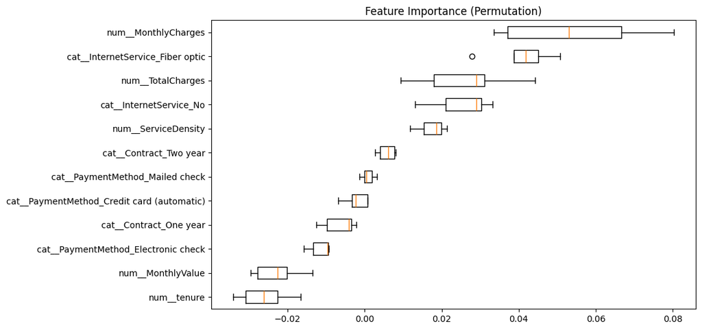

```python
y_pred_probs = model.predict(X_test_processed)
y_pred = (y_pred_probs > 0.4).astype(int)


print("Classification Report:")
print(classification_report(y_test, y_pred))


plt.figure(figsize=(8,6))
fpr, tpr, _ = roc_curve(y_test, y_pred_probs)
plt.plot(fpr, tpr, label=f'AUC = {roc_auc_score(y_test, y_pred_probs):.3f}')
plt.plot([0,1],[0,1], 'k--', label='Random')
plt.xlabel('False Positive Rate')
plt.ylabel('True Positive Rate')
plt.title('ROC Curve')
plt.legend()
plt.show()


def scorer(estimator, X, y):
    y_pred = (estimator.predict(X) > 0.5).astype(int)
    return roc_auc_score(y, y_pred)

try:
    result = permutation_importance(
        model,
        X_test_processed,
        y_test,
        scoring=scorer,
        n_repeats=5,
        random_state=42)

    sorted_idx = result.importances_mean.argsort()

    plt.figure(figsize=(10,6))
    plt.boxplot(result.importances[sorted_idx].T,
               vert=False,
               labels=np.array(preprocessor.get_feature_names_out())[sorted_idx])
    plt.title("Feature Importance (Permutation)")
    plt.show()

except Exception as e:
    print(f"Feature importance skipped due to: {str(e)}")
    print("Proceeding with business impact analysis...")
```

```
45/45 ━━━━━━━━━━━━━━━━━━━━ 0s 8ms/step
              precision    recall  f1-score   support

           0       0.90      0.77      0.83      1035
           1       0.54      0.76      0.63       374

    accuracy                           0.76      1409
   macro avg       0.72      0.76      0.73      1409
weighted avg       0.80      0.76      0.77      1409

45/45 ━━━━━━━━━━━━━━━━━━━━ 0s 2ms/step
```

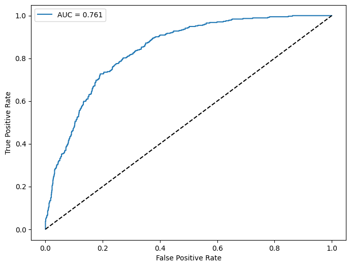

```python
y_pred = (model.predict(X_test_processed) > 0.5).astype(int)


print(classification_report(y_test, y_pred))


plt.figure(figsize=(8,6))
fpr, tpr, _ = roc_curve(y_test, model.predict(X_test_processed))
plt.plot(fpr, tpr, label=f'AUC = {roc_auc_score(y_test, y_pred):.3f}')
plt.plot([0,1],[0,1], 'k--')
plt.xlabel('False Positive Rate')
plt.ylabel('True Positive Rate')
plt.legend()
plt.show()
```

**Projected Savings:**

```python
y_pred_binary = (y_pred_probs > 0.4).astype(int).flatten()
y_test_values = y_test.values

tp = np.sum((y_pred_binary == 1) & (y_test_values == 1))
total_churn = np.sum(y_test_values == 1)
recall = tp / total_churn


avg_clv = 1200
retention_rate = 0.25
savings = tp * retention_rate * avg_clv

print(f"\nBusiness Impact Analysis:")
print(f"- Total churn cases in test set: {total_churn}")
print(f"- True Positives identified: {tp} (Recall: {recall:.1%})")
print(f"- Assumed retention rate: {retention_rate:.0%}")
print(f"- Customer Lifetime Value: ${avg_clv}")
print(f"\n\033[1mProjected Annual Savings: ${savings:,.0f}\033[0m")
```

[output not shown]

# **Conclusion:**

This churn prediction pipeline helps you keep customers pleased by identifying those who could go. It provides straightforward notifications to help your team concentrate on the appropriate individuals at the appropriate times. Early issue solving will save time and effort while strengthening connections and expanding your business.

It helps you retain more clients with less effort by operating silently in the background.